# dwb284 Assignment 9

Question 1: Data file ALLsfilt.RData consists of microarray (log) expression data from 79 different individuals with acute lymphoblastic leukemia (BCR/ABL) and controls (NEG). The (log) expression data is in the matrix ALLsfilt, with rows representing individual genes, and columns representing tissue samples. The group identities of each column of this matrix is stored in the factor vector mol.biol.

Is this an experimental or observational study?

Observational study

Using an explicit loop in R and lm(), estimate p-values for each gene, with the null hypothesis that gene expression does not differ between BCR/ABL and NEG groups, and plot the distribution of these p-values. Comment on the features of this distribution.

The features of this distribution are uniform with a spike near zero, corresponding to some genes with small p-values.

Note that this is identical to using rowttest(), but that function is not allowed for this assignment. Give a list of differentially expressed genes for which you estimate that less than 20% of the gene list are false positives.

genes_of_interest

What multiple testing correction would you do to ensure this?

BH or Storey

Would a Bonferroni correction be appropriate- why or why not?

No, this would be too stringent for an exploratory study. You would be confident that you had no errors, but you would be missing too many genes of interest.

Show the R code of your analysis and the number of genes in your final gene list.

593 genes

```r
library("multtest") #for BH
```

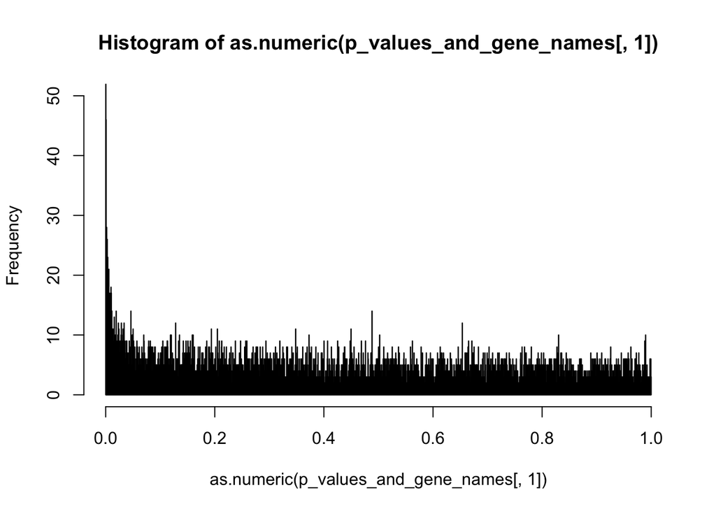

```r
load(file="ALLsfilt.RData")
p_values_and_gene_names<-c()#this will be a matrix with p values and corresponding gene names
for (row in 1:nrow(ALLsfilt)) {
  exp <- ALLsfilt[row,]
  m <- lm(exp~mol.biol)
  anova_vector<-anova(m)
  p_values_and_gene_names<-rbind(p_values_and_gene_names,c(anova_vector[1,"Pr(>F)"], rownames(ALLsfilt)[row]))
}

hist(as.numeric(p_values_and_gene_names[,1]), breaks=3000, ylim=c(0,50)) #distribution of p values
```

```r
mt <- mt.rawp2adjp(as.numeric(p_values_and_gene_names[,1]), proc=c("BH"))
d_sig_fdr <- data.frame(mt$adjp) #adjusted p values
apply_list<-apply(d_sig_fdr, 2, function(x) sum(x < 0.2)) # 20% false discovery rate
p<-p_values_and_gene_names[order(p_values_and_gene_names[,1]),]#ascending order of p values
genes_of_interest<-p[1:apply_list[2],2] #apply_list[2] is the named int of the BH genes where x < 0.2. It is 593 in this example
genes_of_interest # a list of genes who have a BH p-value of 0.2 or lower
```

```
##   [1] "35831_at"                    "1211_s_at"
##   [3] "35125_at"                    "37105_at"
##   [5] "37398_at"                    "37351_at"
##   [7] "38085_at"                    "35051_at"
##   [9] "41478_at"                    "766_at"
##  [11] "39317_at"                    "41138_at"
##  [13] "34237_at"                    "39143_at"
##  [15] "36795_at"                    "41439_at"
##  [17] "37762_at"                    "40479_at"
##  [19] "41071_at"                    "1107_s_at"
##  [21] "38408_at"                    "36131_at"
##  [23] "33358_at"                    "32961_at"
##  [25] "38112_g_at"                  "32696_at"
##  [27] "38631_at"                    "37147_at"
##  [29] "39753_at"                    "39372_at"
```

[output cut: 282 more lines]

Question 2: An experiment on the effects of nutrients on Staph. Aureus growth was performed. Two nutrients were added to agar plates for testing: nutrient A and nutrient B. A was added at four concentrations; B at three concentrations. Response was measured by cell density. Four replicates of each treatment combination were used. All 48 samples were independent biological replicates. Because this was a large experiment four separate incubators were needed for all the replicates– one of every treatment combination was in each incubator, and all incubators were set to the same temperature. The data are in staph.txt.

Note: use str() in R to check that the variable types are correct, and correct if necessary.

What kind of experimental design is this?

Factorial Design with blocking

Why was the incubator number recorded when the temperate was set to the same value for each?

The incubator was numbered because it was a potentially confounding variable. Even if the incubators were measured at the same temperature it is possible that a temperature change occured that was not recorded. This experiment shows that both the A level and the B level as well as the interaction between the two have a statistically significant influence on the density.

What is the name given to this kind of variable?

confounding variable

Analyze this experiment, including checking model assumptions: show and comment on the diagnostic plots. Show your final statistical model and give your conclusions from the analysis.

```r
staph <- read.csv(file="staph.txt", sep="\t", header=TRUE)
staph$Incubator<-factor(staph$Incubator)#refactor
staph$A_level<-factor(staph$A_level)#refactor
staph$B_level<-factor(staph$B_level)#refactor
summary(lm(staph$DENSITY ~ Incubator + A_level * B_level, data=staph))#block incubator, interaction term of A level and B level
```

```
##
## Call:
## lm(formula = staph$DENSITY ~ Incubator + A_level * B_level, data = staph)
##
## Residuals:
##        Min         1Q     Median         3Q        Max
## -7.103e+09 -6.675e+08 -6.523e+07  7.018e+08  6.002e+09
##
## Coefficients:
##                     Estimate Std. Error t value Pr(>|t|)
## (Intercept)       -707144729 1217078470  -0.581 0.565176
## Incubator2         729541667  888828443   0.821 0.417656
## Incubator3        1375490000  888828443   1.548 0.131273
## Incubator4         843210250  888828443   0.949 0.349682
## A_level2            23969250 1539496023   0.016 0.987672
## A_level3           370934250 1539496023   0.241 0.811088
## A_level4          1075084250 1539496023   0.698 0.489860
## B_level2            24234250 1539496023   0.016 0.987535
## B_level3           156059250 1539496023   0.101 0.919870
## A_level2:B_level2  111780750 2177176155   0.051 0.959362
## A_level3:B_level2 1790415750 2177176155   0.822 0.416777
## A_level4:B_level2 -248484250 2177176155  -0.114 0.909825
## A_level2:B_level3 1702555750 2177176155   0.782 0.439789
## A_level3:B_level3 4238090750 2177176155   1.947 0.060137 .
## A_level4:B_level3 9098940750 2177176155   4.179 0.000202 ***
## ---
## Signif. codes:  0 '***' 0.001 '**' 0.01 '*' 0.05 '.' 0.1 ' ' 1
##
## Residual standard error: 2.177e+09 on 33 degrees of freedom
## Multiple R-squared:  0.7248, Adjusted R-squared:  0.6081
## F-statistic: 6.208 on 14 and 33 DF,  p-value: 8.188e-06
```

```r
anova(lm(staph$DENSITY ~ Incubator + A_level * B_level, data=staph))
```

```
## Analysis of Variance Table
##
## Response: staph$DENSITY
##                 Df     Sum Sq    Mean Sq F value    Pr(>F)
## Incubator        3 1.1546e+19 3.8487e+18  0.8119 0.4964173
## A_level          3 1.1872e+20 3.9574e+19  8.3488 0.0002865 ***
## B_level          2 1.4733e+20 7.3666e+19 15.5411 1.755e-05 ***
## A_level:B_level  6 1.3440e+20 2.2400e+19  4.7257 0.0014198 **
## Residuals       33 1.5642e+20 4.7401e+18
## ---
## Signif. codes:  0 '***' 0.001 '**' 0.01 '*' 0.05 '.' 0.1 ' ' 1
```

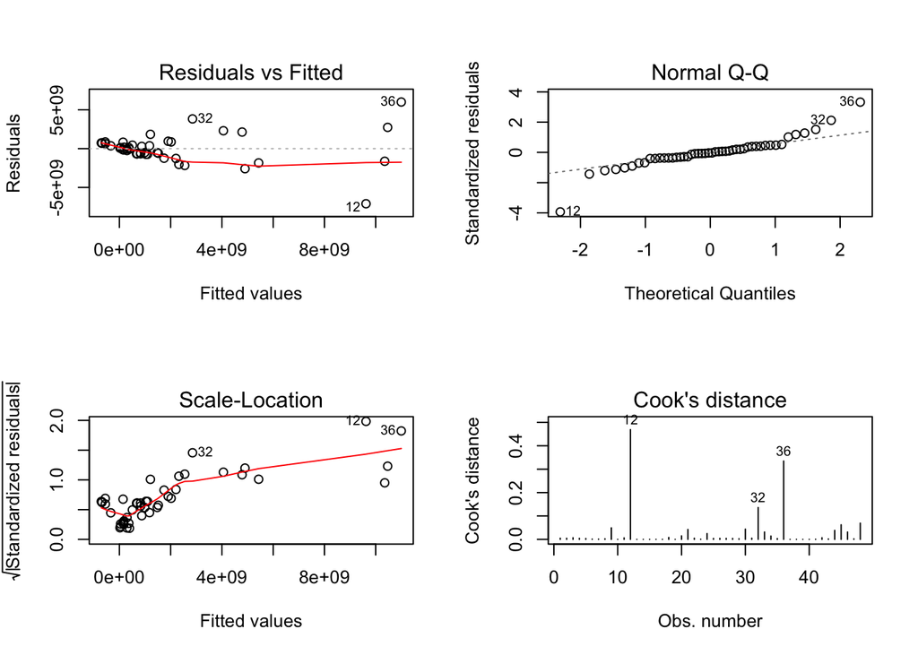

```r
par(mfrow=c(2,2))
lm.density <- (lm(staph$DENSITY ~ Incubator + A_level * B_level, data=staph))
plot(lm.density, which=1:4)
```

The diagnostic plots show that the Residuals vs Fitted are not quite a straight line and most values are clustered in one spot. The normal Q-Q plot is decent with only 3 extreme outliers. The scale-location plot is also mostly clustered in one place. The Cook’s distance shows that point 12 is more important than all the others in this model. This shows that the data is not normal so I will try to transform it.

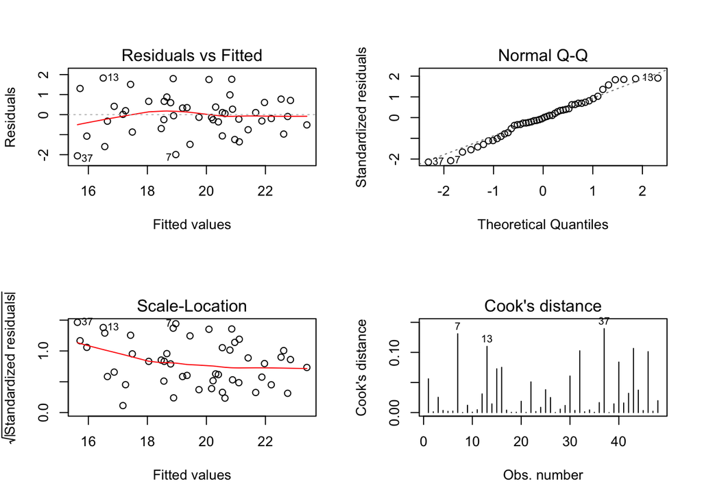

```r
par(mfrow=c(2,2))
lm.density <- (lm(log(staph$DENSITY) ~ Incubator + A_level * B_level, data=staph))
plot(lm.density, which=1:4)
```

This transformed dataset looks a lot better. The RvF plot is not heteroskedastic. No number appears more important in the cook’s distance than any other.

```r
summary(lm(log(staph$DENSITY) ~ Incubator + A_level * B_level, data=staph))
```

```
##
## Call:
## lm(formula = log(staph$DENSITY) ~ Incubator + A_level * B_level,
##     data = staph)
##
## Residuals:
##      Min       1Q   Median       3Q      Max
## -2.05791 -0.55914 -0.02123  0.62018  1.82725
##
## Coefficients:
##                   Estimate Std. Error t value Pr(>|t|)
## (Intercept)       15.71776    0.64648  24.313  < 2e-16 ***
## Incubator2         0.78466    0.47212   1.662 0.105987
## Incubator3         0.22944    0.47212   0.486 0.630195
## Incubator4        -0.08895    0.47212  -0.188 0.851707
## A_level2           0.92687    0.81773   1.133 0.265190
## A_level3           3.24449    0.81773   3.968 0.000369 ***
## A_level4           4.45696    0.81773   5.450 4.88e-06 ***
## B_level2           1.54177    0.81773   1.885 0.068203 .
## B_level3           2.94028    0.81773   3.596 0.001043 **
## A_level2:B_level2  0.37090    1.15645   0.321 0.750445
## A_level3:B_level2  0.12368    1.15645   0.107 0.915479
## A_level4:B_level2 -1.40378    1.15645  -1.214 0.233414
## A_level2:B_level3  1.29941    1.15645   1.124 0.269284
## A_level3:B_level3  0.06442    1.15645   0.056 0.955914
## A_level4:B_level3 -0.49719    1.15645  -0.430 0.670045
## ---
## Signif. codes:  0 '***' 0.001 '**' 0.01 '*' 0.05 '.' 0.1 ' ' 1
##
## Residual standard error: 1.156 on 33 degrees of freedom
## Multiple R-squared:  0.8211, Adjusted R-squared:  0.7452
## F-statistic: 10.82 on 14 and 33 DF,  p-value: 1.338e-08
```

```r
anova(lm(log(staph$DENSITY) ~ Incubator + A_level * B_level, data=staph))
```

```
## Analysis of Variance Table
##
## Response: log(staph$DENSITY)
##                 Df  Sum Sq Mean Sq F value    Pr(>F)
## Incubator        3   5.547   1.849  1.3826    0.2653
## A_level          3 110.466  36.822 27.5330 4.164e-09 ***
## B_level          2  80.473  40.237 30.0863 3.649e-08 ***
## A_level:B_level  6   6.091   1.015  0.7590    0.6071
## Residuals       33  44.134   1.337
## ---
## Signif. codes:  0 '***' 0.001 '**' 0.01 '*' 0.05 '.' 0.1 ' ' 1
```

The new conclusion of this new model shows that A level and B level both have a statistically significant impact on the density, but the interaction no longer does.